# MTH6139 Time Series Coursework 1

Time Series Analysis on Seatbelts Dataset Using Prophet

Yusuf Khan

March 2024

# Forecasting using Meta’s Prophet

## 1.1 : What is prophet?

Prophet from meta is a procedure which forecasts time series data. It can be used in r by `install.packages("prophet")`.

## 1.2 : Seatbelts Data

I will doing a time series analysis using the Seatbelts dataset in R. This is data of in drivers in Great Britain killed with monthly time periods and yearly seasonality. Because we are only interested in total number of drivers killed, we will look only at the first column. In order to use `prophet()` the data needs to be a data frame with the time column called ds and the data column called y. This is essential for prophet to work. We also need the to convert the times into a vector of dates (as R usually sees this as just some random characters). For this we use the zoo package.

```r
date <- zoo::as.yearmon(time(Seatbelts))
date
```

```
##   [1] "Jan 1969" "Feb 1969" "Mar 1969" "Apr 1969" "May 1969" "Jun 1969"
##   [7] "Jul 1969" "Aug 1969" "Sep 1969" "Oct 1969" "Nov 1969" "Dec 1969"
##  [13] "Jan 1970" "Feb 1970" "Mar 1970" "Apr 1970" "May 1970" "Jun 1970"
##  [19] "Jul 1970" "Aug 1970" "Sep 1970" "Oct 1970" "Nov 1970" "Dec 1970"
##  [25] "Jan 1971" "Feb 1971" "Mar 1971" "Apr 1971" "May 1971" "Jun 1971"
##  [31] "Jul 1971" "Aug 1971" "Sep 1971" "Oct 1971" "Nov 1971" "Dec 1971"
##  [37] "Jan 1972" "Feb 1972" "Mar 1972" "Apr 1972" "May 1972" "Jun 1972"
##  [43] "Jul 1972" "Aug 1972" "Sep 1972" "Oct 1972" "Nov 1972" "Dec 1972"
##  [49] "Jan 1973" "Feb 1973" "Mar 1973" "Apr 1973" "May 1973" "Jun 1973"
##  [55] "Jul 1973" "Aug 1973" "Sep 1973" "Oct 1973" "Nov 1973" "Dec 1973"
##  [61] "Jan 1974" "Feb 1974" "Mar 1974" "Apr 1974" "May 1974" "Jun 1974"
##  [67] "Jul 1974" "Aug 1974" "Sep 1974" "Oct 1974" "Nov 1974" "Dec 1974"
##  [73] "Jan 1975" "Feb 1975" "Mar 1975" "Apr 1975" "May 1975" "Jun 1975"
##  [79] "Jul 1975" "Aug 1975" "Sep 1975" "Oct 1975" "Nov 1975" "Dec 1975"
##  [85] "Jan 1976" "Feb 1976" "Mar 1976" "Apr 1976" "May 1976" "Jun 1976"
```

[output cut: 17 more lines]

```r
Seatbelts.df <- data.frame(ds = date, y = Seatbelts[,1])
head(Seatbelts.df)
```

```
##         ds   y
## 1 Jan 1969 107
## 2 Feb 1969  97
## 3 Mar 1969 102
## 4 Apr 1969  87
## 5 May 1969 119
## 6 Jun 1969 106
```

## 1.3 : Plot and Decomposition

We can plot the Time Series and We can also use the function `plot(decompose())` to plot the components of the Time Series in order to visualise it. Again, these are the trend, the seasonality and the error.

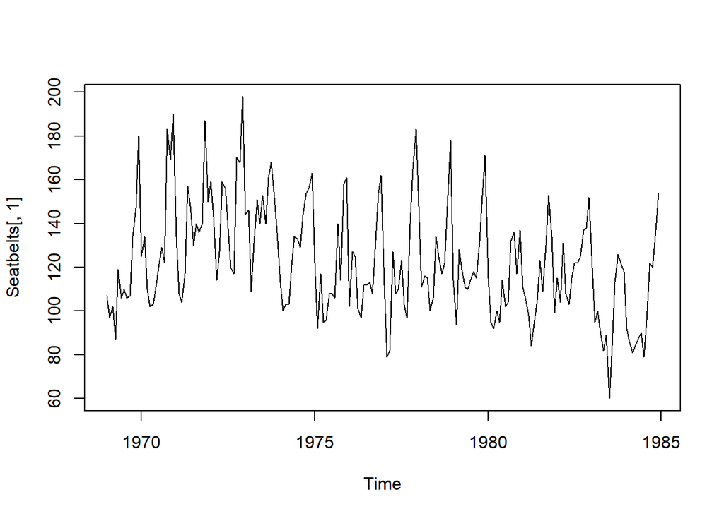

```r
plot(Seatbelts[,1])
```

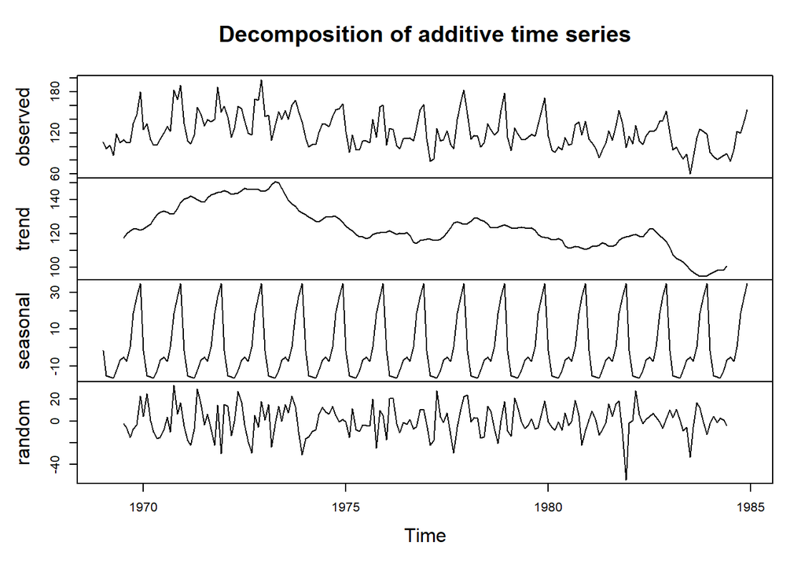

```r
plot(decompose(Seatbelts[,1]))
```

From the plot of the Time Series wan see that there is no obvious change in variance with time so it seems the Time Series is Homoskedastic. From the decompose plot, we caan see that there is an overall decreasing trend. We can also see a pattern in the seasonality; there is an increase towards the end of the year. Later on, we will see the same thing using Prophet. From the residual error plot, we can see that there is no obvious trend or change in variance so it seems like it is stationary.

## 1.4 Forecasting

Now that we have formatted the data properly we can use prophet to forecast. To do this we need to make a new data frame of how much time we wish to forecast (predict). We will be forecasting one year and since we have monthly time periods so we will do monthly frequency and 12 periods.

```r
model <- prophet::prophet(Seatbelts.df)
```

```
## Disabling weekly seasonality. Run prophet with weekly.seasonality=TRUE to override this.
```

```
## Disabling daily seasonality. Run prophet with daily.seasonality=TRUE to override this.
```

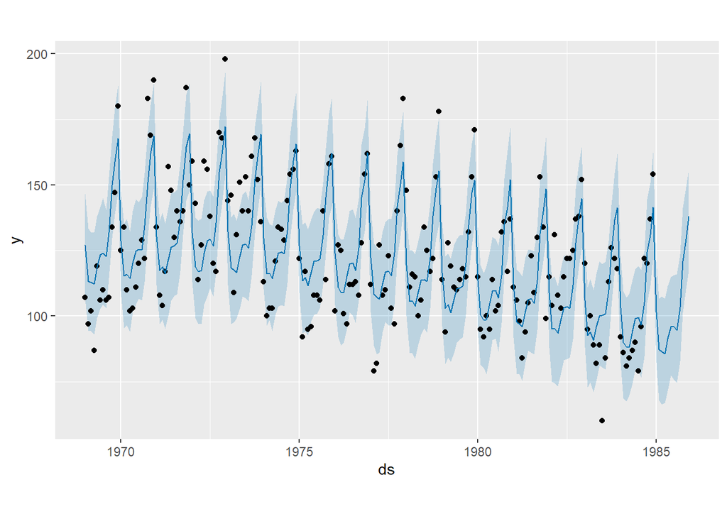

```r
forecastdates <- prophet::make_future_dataframe(model, periods = 12, freq = "month")
forecast <- predict(model, forecastdates)
plot(model, forecast)
```

The dots on the plot are the historical observed value from data. The blue line is the forecasted (predicted) values and the shaded blue area is the uncertainty of our forecast.

## 1.5 : Decomposition using Prophet

Similar to before, but now also using our forecasted values, we can plot the components of our Time Series using prophet.

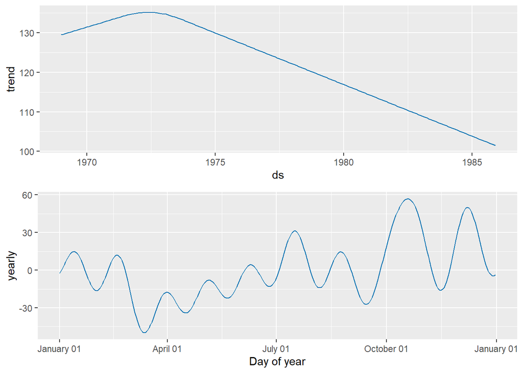

```r
prophet::prophet_plot_components(model, forecast)
```

From this we can again see that there is an overall decline in the trend; the total number of drivers killed has been decreasing over time. We can also see the trend in seasonality; the trend during the year. It shows that there seems to be an increase in deaths during the winter periods which could be due to icy road conditions.